# Differential expression

Francisca Samsing

11/10/2018

## Experiment overview

Atlantic salmon kidney (ASK) cells were infected in triplicate wells with POMV (isolate 14-01514) and ISAV (isolate Glesvaer-2-90), both part of the collections of specimens kept at the Australian Animal Health Laboratory (AAHL) in Geelong. Infected cells were sampled 6 and 24 hours post infection (hpi). Negative control cells were harvested at time 0, before infection. From infected and non-infected ASK cells, we extracted RNA for transcriptome sequencing (RNA-sequencing) to examine both viral and host gene expression profiles. This experiment has a total of 15 replicated samples.

## Analysis pipeline

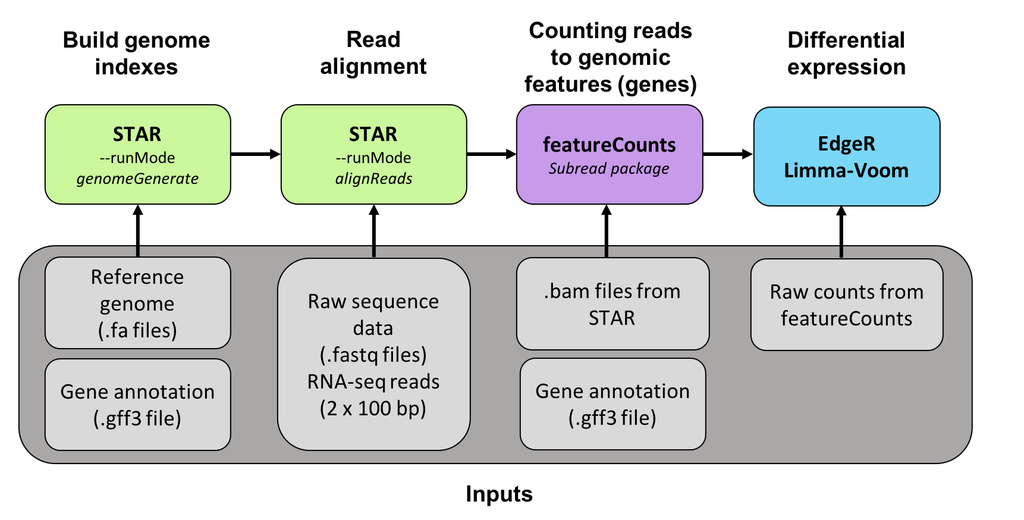

## Differential Expression with Limma-Voom

A great tutorial https://combine-australia.github.io/RNAseq-R/06-rnaseq-day1.html

```r
# Loading the required packaged
library(edgeR)
library(limma)
library(Glimma)
library(RColorBrewer)
library(ggplot2)
library(gplots)
library(genefilter)
library(pheatmap)
```

### Load raw counts

```r
# Import raw Counts, re-name and reorder columns
countdata <- read.csv('Data/read_counts_clean.txt', header = TRUE, sep = '\t',  row.names = 'Geneid')

colnames(countdata) <- c('ISAV24.R1', 'ISAV24.R2', 'ISAV24.R3', 'ISAV6.R1', 'ISAV6.R2', 'ISAV6.R3',
                      'Control.R1', 'Control.R2', 'Control.R3',
                      'POMV24.R1', 'POMV24.R2', 'POMV24.R3', 'POMV6.R1', 'POMV6.R2', 'POMV6.R3')

countdata2 <- countdata[,c(7,8,9,13,14,15,4,5,6,10,11,12,1,2,3)]

DataGroups <- c('Control', 'Control', 'Control', 'POMV6', 'POMV6', 'POMV6',
            'ISAV6', 'ISAV6', 'ISAV6', 'POMV24', 'POMV24', 'POMV24',
            'ISAV24', 'ISAV24', 'ISAV24')

head(countdata2)
```

```
##              Control.R1 Control.R2 Control.R3 POMV6.R1 POMV6.R2 POMV6.R3
## LOC106560212        135        167        149      167      126      144
## LOC106607996        374        390        396      415      411      403
## LOC106601976         14         18         11        9        9       15
## LOC106560213          0          0          0        0        1        0
## LOC106566220          0          0          0        0        0        1
## LOC106571988          0          0          0        0        0        0
##              ISAV6.R1 ISAV6.R2 ISAV6.R3 POMV24.R1 POMV24.R2 POMV24.R3
## LOC106560212      138      136      172        41        40        40
## LOC106607996      290      361      485        41        21        18
## LOC106601976       19       14       23         3         2         3
## LOC106560213        0        0        0         1         0         0
## LOC106566220        0        0        1         2         0         1
## LOC106571988        0        0        0         0         0         0
##              ISAV24.R1 ISAV24.R2 ISAV24.R3
## LOC106560212       115        84        76
## LOC106607996       208       207       183
## LOC106601976         5         7        13
## LOC106560213         0         0         0
## LOC106566220         0         0         0
## LOC106571988         0         0         0
```

```r
# Create DGE (Differential gene expression) object using EdgeR
dgList <- DGEList(counts=countdata2,group=factor(DataGroups))
y <- dgList # Rename the object to y to keep a clean version of the object (dgList)
head(y$counts)
```

```
##              Control.R1 Control.R2 Control.R3 POMV6.R1 POMV6.R2 POMV6.R3
## LOC106560212        135        167        149      167      126      144
## LOC106607996        374        390        396      415      411      403
## LOC106601976         14         18         11        9        9       15
## LOC106560213          0          0          0        0        1        0
## LOC106566220          0          0          0        0        0        1
## LOC106571988          0          0          0        0        0        0
##              ISAV6.R1 ISAV6.R2 ISAV6.R3 POMV24.R1 POMV24.R2 POMV24.R3
## LOC106560212      138      136      172        41        40        40
## LOC106607996      290      361      485        41        21        18
## LOC106601976       19       14       23         3         2         3
## LOC106560213        0        0        0         1         0         0
## LOC106566220        0        0        1         2         0         1
## LOC106571988        0        0        0         0         0         0
##              ISAV24.R1 ISAV24.R2 ISAV24.R3
## LOC106560212       115        84        76
## LOC106607996       208       207       183
## LOC106601976         5         7        13
## LOC106560213         0         0         0
## LOC106566220         0         0         0
## LOC106571988         0         0         0
```

The following shows a table of out groups and library sizes, BEFORE normalizing our data for library size.

```r
y$samples
```

```
##              group lib.size norm.factors
## Control.R1 Control 22942872            1
## Control.R2 Control 25357950            1
## Control.R3 Control 23873071            1
## POMV6.R1     POMV6 25264030            1
## POMV6.R2     POMV6 24881170            1
## POMV6.R3     POMV6 24372331            1
## ISAV6.R1     ISAV6 21665879            1
## ISAV6.R2     ISAV6 23113962            1
## ISAV6.R3     ISAV6 24749842            1
## POMV24.R1   POMV24  8702320            1
## POMV24.R2   POMV24  8158941            1
## POMV24.R3   POMV24  7716112            1
## ISAV24.R1   ISAV24 21373231            1
## ISAV24.R2   ISAV24 19367863            1
## ISAV24.R3   ISAV24 15833324            1
```

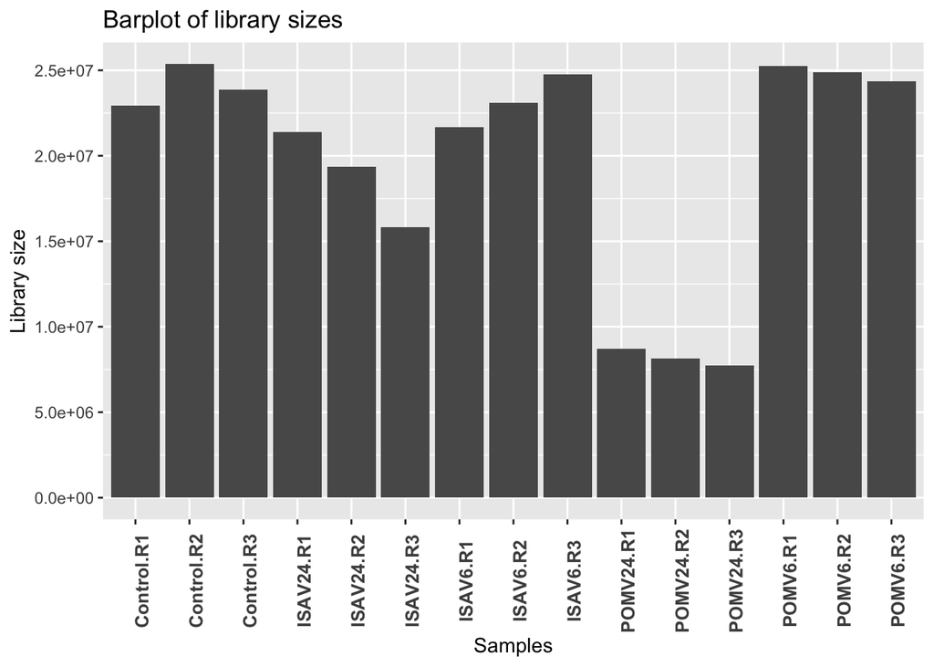

```r
# Visualizing Library Sizes
library.size <- as.data.frame(y$samples$lib.size)
library.size$samples <- colnames(y)
colnames(library.size) <- c('library_sizes', 'samples')

ggplot(library.size, aes(samples, library_sizes)) + geom_col() +
  labs(x = "Samples",
       y= "Library size",
       title = "Barplot of library sizes") +
  theme(axis.text.x = element_text(face="bold", size=10, angle=90))
```

### Filtering

Genes with very low counts across all libraries provide little evidence for differential expression. In the biological point of view, a gene must be expressed at some minimal level before it is likely to be translated into a protein or to be biologically important.

In addition, the pronounced discreteness of these counts interferes with some of the statistical approximations that are used later in the pipeline. These genes should be filtered out prior to further analysis.

As a general rule, a good threshold can be chosen by identifying the counts per million (CPM) that corresponds to a raw count of 10, which in this case is about 0.5. Here we filter to retain genes that are represented at least 0.5 counts per million (cpm) in at least 3 samples.

```r
# Get the counts per million
countsPerMillion <- cpm(y)
countCheck <- countsPerMillion > 0.5
#head(countCheck) ## produces a matrix of Trues and False
```

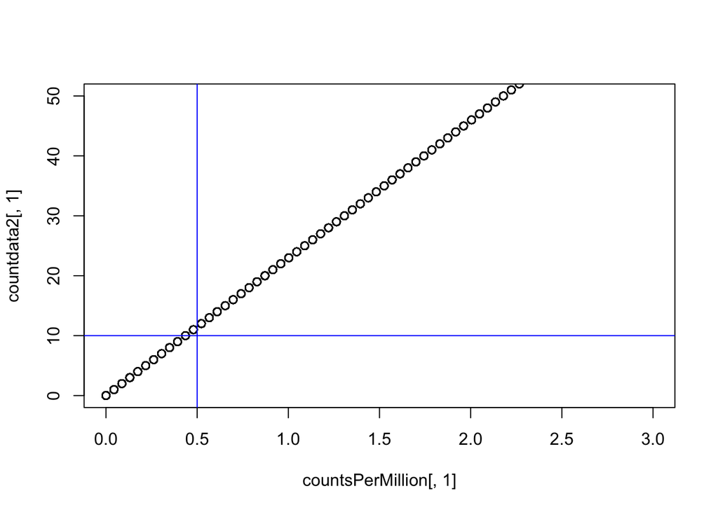

```r
# Let's have a look and see whether our threshold of 0.5 does indeed correspond to a count of about 10-15
# We will look at the first sample
plot(countsPerMillion[,1],countdata2[,1], ylim=c(0,50),xlim=c(0,3))
# Add a vertical line at 0.5 CPM
abline(v=0.5, col = 'blue')
abline(h=10, col = 'blue')
```

```r
#Apply filter
keep <- which(rowSums(countCheck) >= 3) # 3 samples
y <- y[keep,]
y$samples$lib.size <- colSums(y$counts)
```

### Normalization

edgeR (and limma-voom) are concerned with differential expression analysis rather than with the quantification of expression levels. It is concerned with relative changes in expression levels between conditions, but not directly with estimating absolute expression levels. This greatly simpliflies the technical infuences that need to be taken into account, because any technical factor that is unrelated to the experimental conditions should cancel out of any differential expression analysis. For example, read counts can generally be expected to be proportional to length as well as to expression for any transcript, but edgeR does not generally need to adjust for gene length because gene length has the same relative influence on the read counts for each RNA sample.

First we can look at a boxplot of logcounts before normalizing the data.

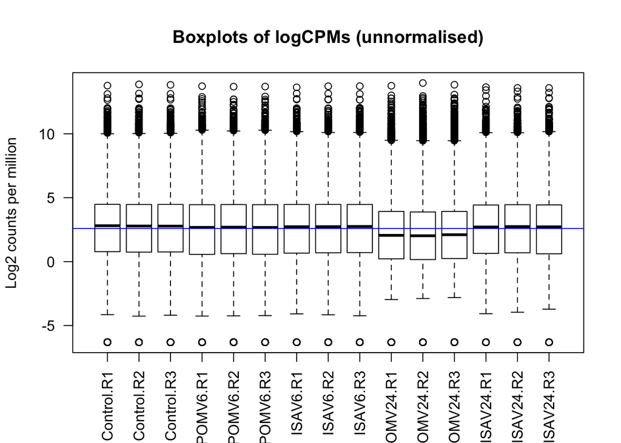

```r
# Get log2 counts per million
logcounts <- cpm(y,log=TRUE)
# Check distributions of samples using boxplots
boxplot(logcounts, xlab="", ylab="Log2 counts per million",las=2)
# Let's add a blue horizontal line that corresponds to the median logCPM
abline(h=median(logcounts),col="blue")
title("Boxplots of logCPMs (unnormalised)")
```

We will normalize our data using the TMM (trimmed mean of M) method.

```r
# Normalization using TMM method
# TMM normalization is performed to eliminate composition biases between libraries.
y <- calcNormFactors(y, method="TMM")
y$samples
```

```
##              group lib.size norm.factors
## Control.R1 Control 22910094    1.1233629
## Control.R2 Control 25323112    1.1033817
## Control.R3 Control 23840449    1.1022899
## POMV6.R1     POMV6 25232567    1.0507664
## POMV6.R2     POMV6 24847576    1.0505609
## POMV6.R3     POMV6 24341645    1.0477065
## ISAV6.R1     ISAV6 21638203    1.0628924
## ISAV6.R2     ISAV6 23084528    1.0656690
## ISAV6.R3     ISAV6 24718431    1.0642566
## POMV24.R1   POMV24  8684092    0.7815221
## POMV24.R2   POMV24  8142235    0.7607662
## POMV24.R3   POMV24  7699471    0.7852240
## ISAV24.R1   ISAV24 21346294    1.0285454
## ISAV24.R2   ISAV24 19342906    1.0485906
## ISAV24.R3   ISAV24 15814537    1.0426002
```

The performance of the TMM normalization procedure can be examined using mean-difference (MD) plots. Ideally, the bulk of genes should be centred at a log-fold change of zero. This indicates that any composition bias between libraries has been successfully removed. This quality check should be repeated by constructing a MD plot for each sample.

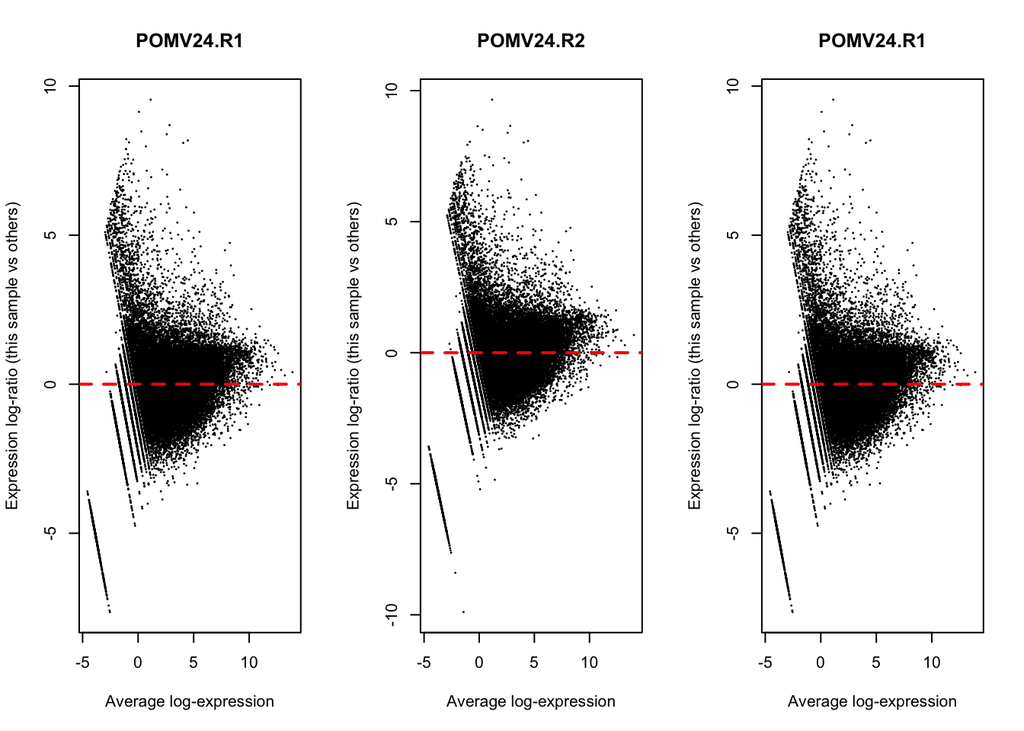

```r
par(mfrow=c(1,3))
plotMD(cpm(y, log=TRUE), column=10) # the column in indicates what sample I want to make my plot for
abline(h=0, col="red", lty=2, lwd=2)
plotMD(cpm(y, log=TRUE), column=11)
abline(h=0, col="red", lty=2, lwd=2)
plotMD(cpm(y, log=TRUE), column=10)
abline(h=0, col="red", lty=2, lwd=2)
```

MD plots look OK, let’s do some post-normalization data exploration before the differential expression analysis.

### Data Exploration

The data can be explored by generating multi-dimensional scaling (MDS) plots, which show the differences between the expression profiles of different samples in two dimensions. Data can also be explore using heatmaps of the variance of logcounts accross samples.

> Hierarchical clustering with heatmaps for the top 100 genes with the highest variance

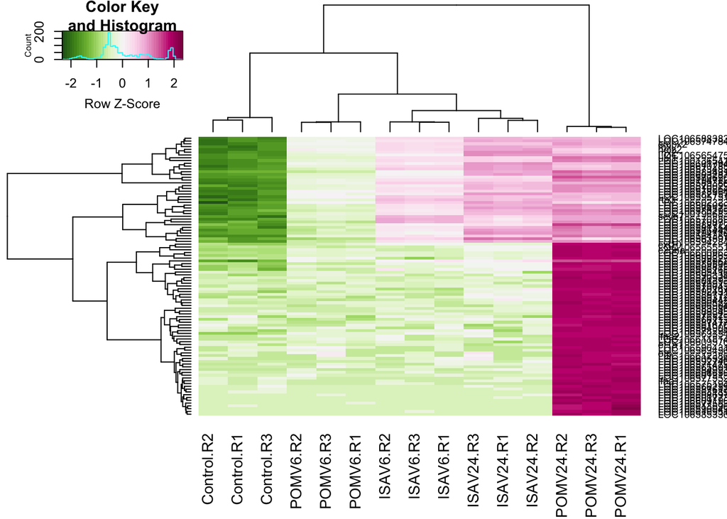

> Hierarchical clustering with heatmaps for the top 500 genes with the highest variance

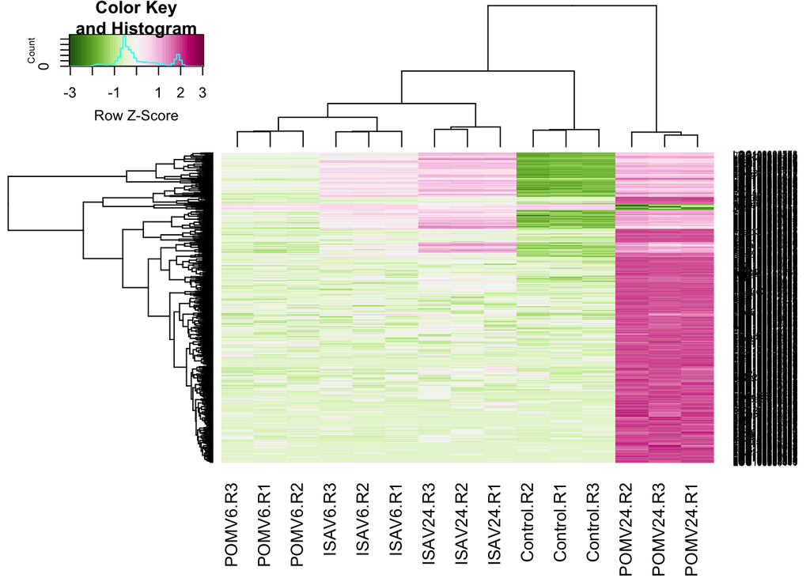

“Row Z scores” are a scaling parameter where values have been normalized to SD units by: z = (x - mean)/sd

> Hierarchical clustering with heatmaps for the top 1000 genes with the highest variance

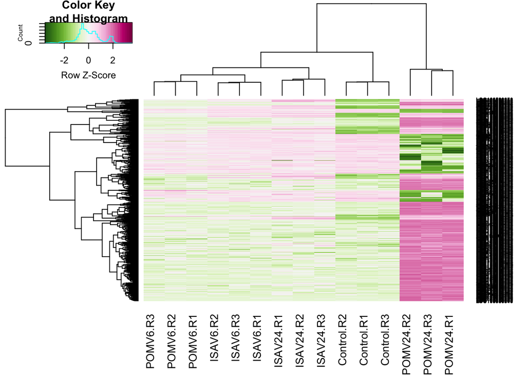

The entire assumption of EdgeR and other programs that detect differential expression is that *most* genes don’t change. If everything is changing all over the place then the scaling strategies they use can be way off - you can actually end up with a situation where something that is upregulated is actually downregulated, etc. So, it’s worth having a visual check of a heatmap with all the genes, and just make sure this assumption is ok.

Multidimenstional scaling plots can also be used to visualize the clustering of our replicates and treatment conditions.

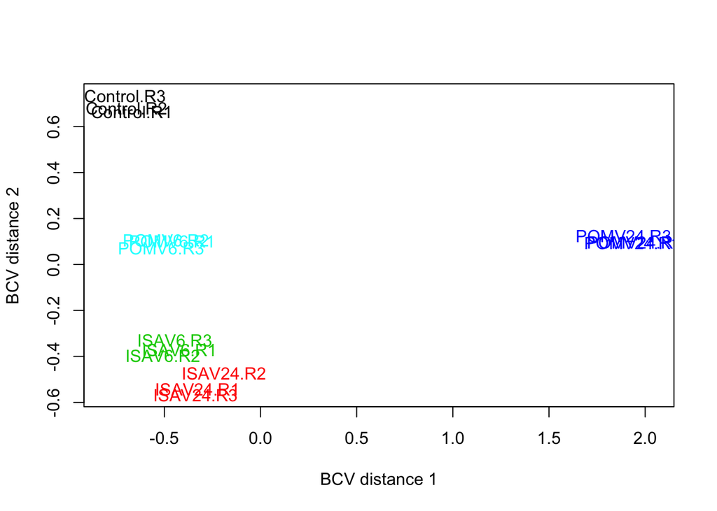

```r
color <- as.numeric(y$samples$group)
points <- as.numeric(y$samples$group)
plotMDS(y, method="bcv", col = as.numeric(y$samples$group))
```

### The design matrix

Build the design matrix using the model.matrix() function from edgeR.

```r
groups <- y$samples$group # get the groups from the y object
design <- model.matrix(~ 0 + groups)
colnames(design) <- levels(y$samples$group)
rownames(design) <- colnames(y)
design
```

```
##            Control ISAV24 ISAV6 POMV24 POMV6
## Control.R1       1      0     0      0     0
## Control.R2       1      0     0      0     0
## Control.R3       1      0     0      0     0
## POMV6.R1         0      0     0      0     1
## POMV6.R2         0      0     0      0     1
## POMV6.R3         0      0     0      0     1
## ISAV6.R1         0      0     1      0     0
## ISAV6.R2         0      0     1      0     0
## ISAV6.R3         0      0     1      0     0
## POMV24.R1        0      0     0      1     0
## POMV24.R2        0      0     0      1     0
## POMV24.R3        0      0     0      1     0
## ISAV24.R1        0      1     0      0     0
## ISAV24.R2        0      1     0      0     0
## ISAV24.R3        0      1     0      0     0
## attr(,"assign")
## [1] 1 1 1 1 1
## attr(,"contrasts")
## attr(,"contrasts")$groups
## [1] "contr.treatment"
```

*The Voom transformation*

Transforms count data to log2-counts per million (logCPM) using the **voom** function in the limma package, estimates the mean-variance relationship and uses this to compute appropriate observation-level weights. The data are then ready for linear modelling.

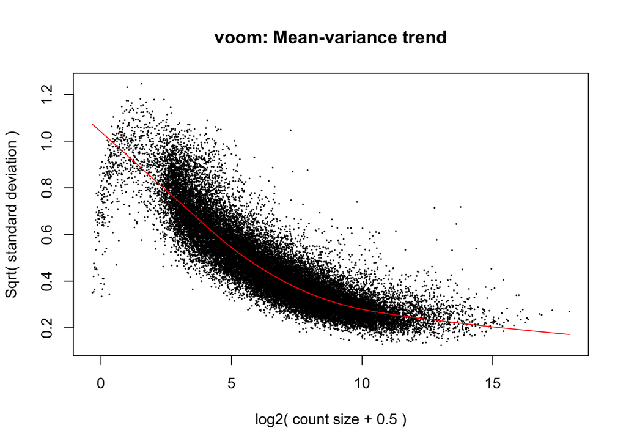

```r
# Voom transform the data
par(mfrow=c(1,1))
v <- voom(y,design,plot = TRUE)
```

[figure not shown]

```r
# The expression values in v$E are already log2 values so we don’t need to log-transform.
par(mfrow=c(1,2))
boxplot(logcounts, xlab="", ylab="Log2 counts per million",las=2,main="Unnormalised logCPM")
abline(h=median(logcounts),col="blue") ## Let's add a blue horizontal line that corresponds to the median logCPM

boxplot(v$E, xlab="", ylab="Log2 counts per million",las=2,main="Voom transformed logCPM")
abline(h=median(v$E),col="blue")
```

Testing for differential expression: fit the linear model and build the contrast matrix.

```r
# Fit the linear model
fit <- lmFit(v)
names(fit)
```

```
##  [1] "coefficients"     "stdev.unscaled"   "sigma"
##  [4] "df.residual"      "cov.coefficients" "pivot"
##  [7] "rank"             "Amean"            "method"
## [10] "design"
```

```r
# Contrast Matrix
cont.matrix  <- makeContrasts(ControlvsPOMV6 = Control - POMV6,
                     ControlvsPOMV24 = Control - POMV24,
                     ControlvsISAV6 = Control - ISAV6,
                     ControlvsISAV24 = Control - ISAV24,
                     POMV6vsISAV6 = POMV6 - ISAV6,
                     POMV24vsISAV24 = POMV24 - ISAV24, levels=design)

fit.cont <- contrasts.fit(fit, cont.matrix)
fit.cont <- eBayes(fit.cont) #This function is used to rank genes in order of evidence for differential expression.
dim(fit.cont)
```

```
## [1] 31592     6
```

```r
# We can use the limma decideTests function to generate
# a quick summary of DE genes for the contrasts.
summa.fit <- decideTests(fit.cont)
summary(summa.fit)
```

```
##        ControlvsPOMV6 ControlvsPOMV24 ControlvsISAV6 ControlvsISAV24
## Down             5661           11158           3161            7053
## NotSig          20692            8836          25861           17695
## Up               5239           11598           2570            6844
##        POMV6vsISAV6 POMV24vsISAV24
## Down           3526          11131
## NotSig        24897           9738
## Up             3169          10723
```

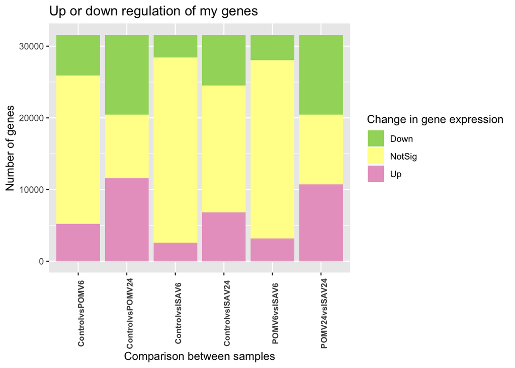

```r
expres <- summary(summa.fit)
expres <- t(expres)
expres <- as.data.frame(expres)

myColors <- c("#A1D76A", "#FFFF99", "#E9A3C9")
ggplot(expres, aes(x = Var1, y = Freq)) + geom_col(aes(fill = Var2)) +
  labs(x = "Comparison between samples",
  y= "Number of genes",
  fill = "Change in gene expression",
  title = "Up or down regulation of my genes") +
  scale_fill_manual(values=myColors) +
  theme(axis.text.x = element_text(face="bold", size=8, angle=90))
```

The following function takes as an arguments a contrast matrix (fit.cont object created in EdgeE), a string indicating the comparison, and a string indicating which table of genes we want (UP, DOWN or ALL).

```r
# The toptable
sig.genes <- function(fit.contrast, mycomparison, upregulated = c('UP', 'DOWN', 'ALL')) {
  x <- topTable(fit = fit.contrast, coef = mycomparison, sort.by="p",n="Inf")
  x_sig <- x[x$adj.P.Val < 0.05,]
  if (upregulated == 'UP') {
    x_UP <- x_sig[x_sig$logFC >= 0.01,]
    #x_UP <- rownames_to_column(x_UP, var = "GeneID")
  } else if (upregulated == 'DOWN') {
    x_DOWN <- x_sig[x_sig$logFC < 0.01,]
    #x_DOWN <- rownames_to_column(x_DOWN, var = "GeneID")
  }
  else {
   x
  }
  }
```

We use the function sig.genes() constructed before to get our comparisons, and save them as csv tables.

```r
ControlvsPOMV6_UP <- sig.genes(fit.cont, mycomparison = "ControlvsPOMV6", 'UP')
ControlvsPOMV6_DOWN <- sig.genes(fit.cont, mycomparison = "ControlvsPOMV6", 'DOWN')
ControlvsPOMV6_ALL <- sig.genes(fit.cont, mycomparison = "ControlvsPOMV6", upregulated = FALSE)

#write.table(ControlvsPOMV6_UP, 'ControlvsPOMV6_UP.csv', row.names = FALSE, sep = ",")
#write.table(ControlvsPOMV6_DOWN, 'ControlvsPOMV6_DOWN.csv', row.names = FALSE, sep = ",")
#write.table(ControlvsPOMV6_ALL, 'ControlvsPOMV6_ALL.csv', row.names = FALSE, sep = ",")
```

## Plot after differential expression

A good tutorial for this https://hbctraining.github.io/Training-modules/Visualization_in_R/lessons/03_advanced_visualizations.html

```r
# THE VOLCANO PLOT
res_table <- ControlvsPOMV6_ALL
## Obtain logical vector regarding whether padj values are less than 0.05
threshold <- res_table$adj.P.Val < 0.05
## Determine the number of TRUE values
length(which(threshold))
```

```
## [1] 10900
```

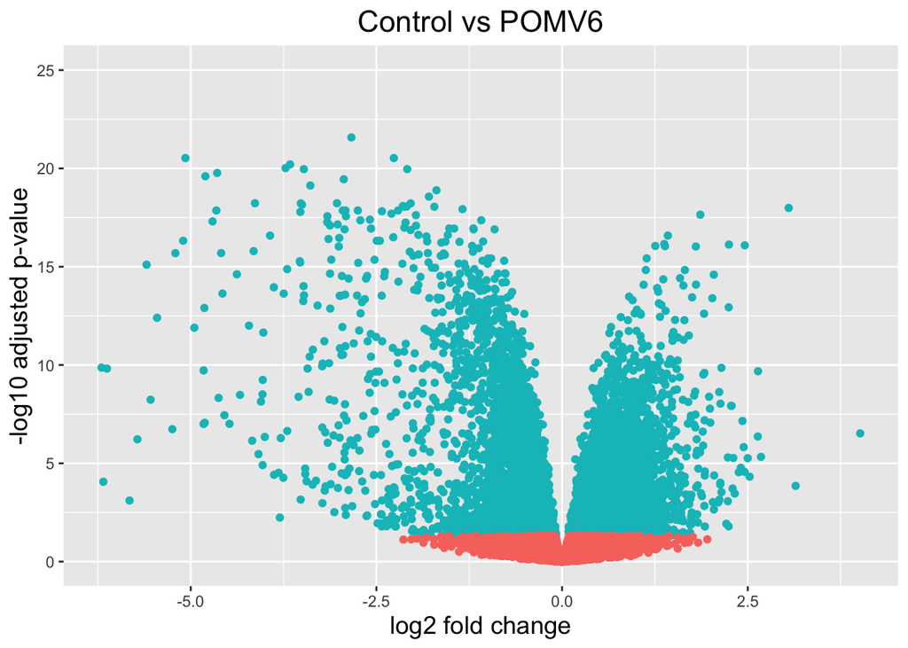

```r
## Add logical vector as a column (threshold) to the res_tableOE
res_table$threshold <- threshold

## Volcano plot
ggplot(res_table) +
  geom_point(aes(x=logFC, y=-log10(adj.P.Val), colour=threshold)) +
  ggtitle("Control vs POMV6") +
  xlab("log2 fold change") +
  ylab("-log10 adjusted p-value") +
  scale_y_continuous(limits = c(0,25)) +
  theme(legend.position = "none",
        plot.title = element_text(size = rel(1.5), hjust = 0.5),
        axis.title = element_text(size = rel(1.25)))
```

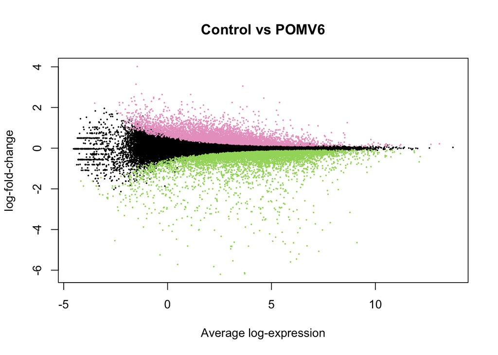

```r
## MA Plots
myColors <- c("#A1D76A", "#E9A3C9")
plotMA(fit.cont,coef=1,status=summa.fit[,"ControlvsPOMV6"], hl.col=myColors, cex = 0.3, legend = FALSE, main = 'Control vs POMV6')
```

```r
## MA Plots in Glimma
glMDPlot(fit.cont, status=summa.fit, counts=v, groups=groups, side.main="Symbols")
```